# Tut02

Chan Kong Yew

January 31, 2022

# Tutorial/Lab 2

##1. In this exercise, we will still be using the College (College.csv) data set from Tutorial/Lab 1

```r
college<-read.csv('College.csv',header = TRUE)
View(college)
```

### a) Use the summary() function to produce a numerical summary of the variables in the data set.

```r
summary(college)
```

```
##                             X       Private        Apps
##  Abilene Christian University:  1   No :212   Min.   :   81
##  Adelphi University          :  1   Yes:565   1st Qu.:  776
##  Adrian College              :  1             Median : 1558
##  Agnes Scott College         :  1             Mean   : 3002
##  Alaska Pacific University   :  1             3rd Qu.: 3624
##  Albertson College           :  1             Max.   :48094
##  (Other)                     :771
##      Accept          Enroll       Top10perc       Top25perc
##  Min.   :   72   Min.   :  35   Min.   : 1.00   Min.   :  9.0
##  1st Qu.:  604   1st Qu.: 242   1st Qu.:15.00   1st Qu.: 41.0
##  Median : 1110   Median : 434   Median :23.00   Median : 54.0
##  Mean   : 2019   Mean   : 780   Mean   :27.56   Mean   : 55.8
##  3rd Qu.: 2424   3rd Qu.: 902   3rd Qu.:35.00   3rd Qu.: 69.0
##  Max.   :26330   Max.   :6392   Max.   :96.00   Max.   :100.0
##
##   F.Undergrad     P.Undergrad         Outstate       Room.Board
##  Min.   :  139   Min.   :    1.0   Min.   : 2340   Min.   :1780
##  1st Qu.:  992   1st Qu.:   95.0   1st Qu.: 7320   1st Qu.:3597
##  Median : 1707   Median :  353.0   Median : 9990   Median :4200
##  Mean   : 3700   Mean   :  855.3   Mean   :10441   Mean   :4358
##  3rd Qu.: 4005   3rd Qu.:  967.0   3rd Qu.:12925   3rd Qu.:5050
##  Max.   :31643   Max.   :21836.0   Max.   :21700   Max.   :8124
##
##      Books           Personal         PhD            Terminal
##  Min.   :  96.0   Min.   : 250   Min.   :  8.00   Min.   : 24.0
##  1st Qu.: 470.0   1st Qu.: 850   1st Qu.: 62.00   1st Qu.: 71.0
##  Median : 500.0   Median :1200   Median : 75.00   Median : 82.0
##  Mean   : 549.4   Mean   :1341   Mean   : 72.66   Mean   : 79.7
##  3rd Qu.: 600.0   3rd Qu.:1700   3rd Qu.: 85.00   3rd Qu.: 92.0
##  Max.   :2340.0   Max.   :6800   Max.   :103.00   Max.   :100.0
##
##    S.F.Ratio      perc.alumni        Expend        Grad.Rate
##  Min.   : 2.50   Min.   : 0.00   Min.   : 3186   Min.   : 10.00
##  1st Qu.:11.50   1st Qu.:13.00   1st Qu.: 6751   1st Qu.: 53.00
##  Median :13.60   Median :21.00   Median : 8377   Median : 65.00
##  Mean   :14.09   Mean   :22.74   Mean   : 9660   Mean   : 65.46
##  3rd Qu.:16.50   3rd Qu.:31.00   3rd Qu.:10830   3rd Qu.: 78.00
##  Max.   :39.80   Max.   :64.00   Max.   :56233   Max.   :118.00
##
```

### b) Using the pairs() function to produce a scatterplot matrix of the following columns: Apps, Accept, Enroll, Grad.Rate.

http://rstudio-pubs-static.s3.amazonaws.com/19462_040b25c21f0a40e8a6f807f164cff2bd.html

1. First obtain another dataframe that consists of 4 columns Apps, Accept, Enroll, Grade.Rate (in this order) and assign to a variable named `smaller_college_df` Ensure that the column names are Apps, Accept, Enroll, Grade.Rate (in this order) Also make sure that `smaller_college_df` is a data.frame
2. Using the pairs function, produce a scatterplot matrix of `smaller_college_df`

```r
# TUTORIAL SUBMISSION ###################################

#Complete implementation...
smaller_college_df <- college[c(which(colnames(college) == 'Apps'),which(colnames(college) == 'Accept'),which(colnames(college) == 'Enroll'),which(colnames(college) == 'Grad.Rate'))]


#ensure that this should be data.frame
class(smaller_college_df)
```

```
## [1] "data.frame"
```

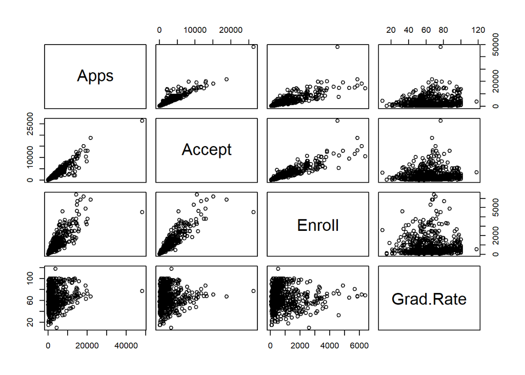

```r
pairs(smaller_college_df)
```

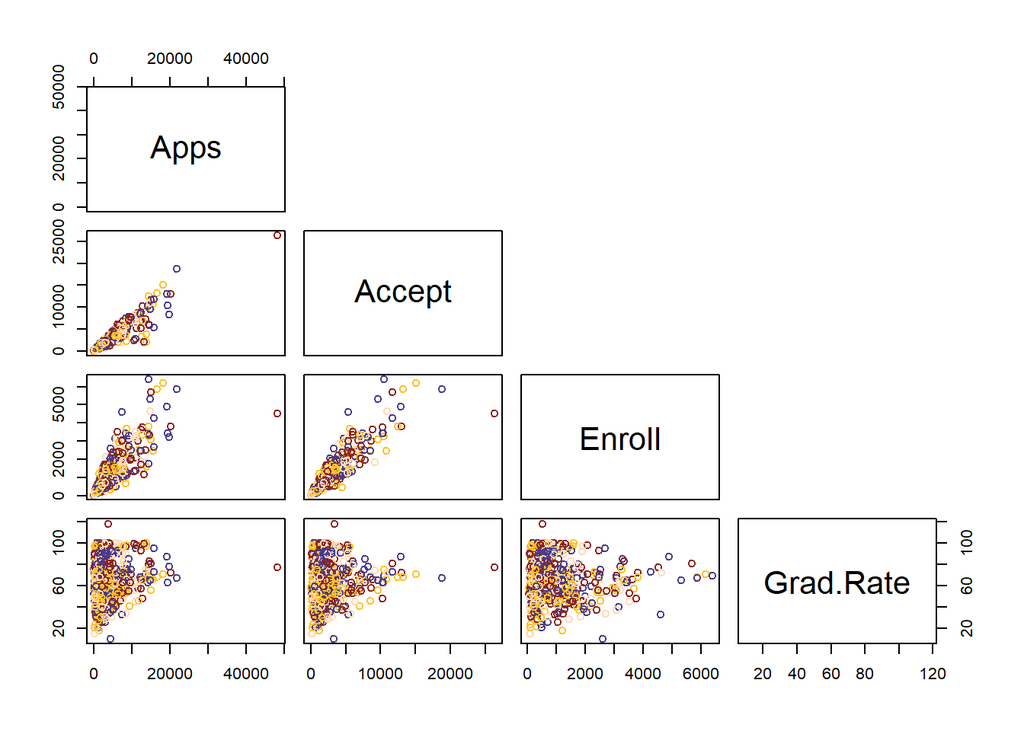

```r
# #######################################################


pFrame <- college[c(which(colnames(college) == 'Apps'),which(colnames(college) == 'Accept'),which(colnames(college) == 'Enroll'),which(colnames(college) == 'Grad.Rate'))]

pairs(pFrame, col=c('peachpuff','darkslateblue','goldenrod1','brown4')[],upper.panel = NULL)
```

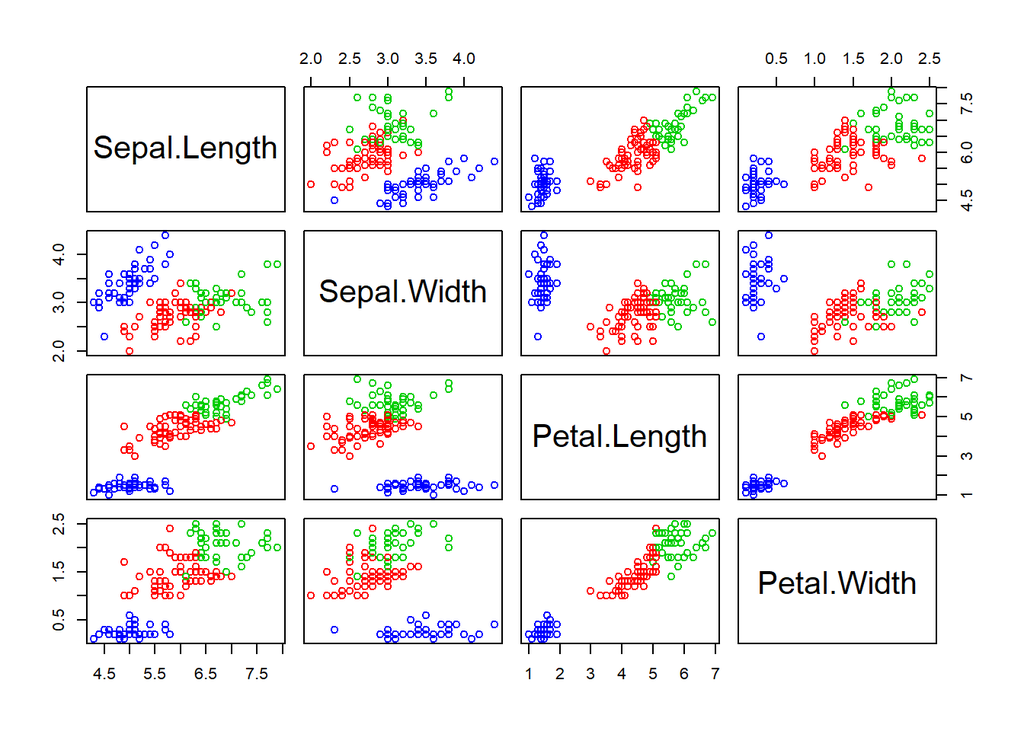

| colName | pair-row | pair-col | corr x-axis | corr y-axis |
| --- | --- | --- | --- | --- |
| Apps | 1 | 1 | Apps | Apps |
| Apps | 1 | 2 | Accept | Apps |
| Apps | 1 | 3 | Enroll | Apps |
| Apps | 1 | 4 | Grad.Rate | Apps |
| Accept | 2 | 1 | Apps | Accept |
| Accept | 2 | 2 | Accept | Accept |
| Accept | 2 | 3 | Enroll | Accept |
| Accept | 2 | 4 | Grad.Rate | Accept |
| Enroll | 3 | 1 | Apps | Enroll |
| Enroll | 3 | 2 | Accept | Enroll |
| Enroll | 3 | 3 | Enroll | Enroll |
| Enroll | 3 | 4 | Grad.Rate | Enroll |
| Grad.Rate | 4 | 1 | Apps | Grad.Rate |
| Grad.Rate | 4 | 2 | Accept | Grad.Rate |
| Grad.Rate | 4 | 3 | Enroll | Grad.Rate |
| Grad.Rate | 4 | 4 | Grad.Rate | Grad.Rate |

```r
# from lecture notes
#Clustering of Iris Plant
Iris.features = iris
#remove the class column
Iris.features$Species <- NULL
#using k-means clustering
results <- kmeans(Iris.features, 3)
pairs(Iris.features, col=c("red","green3", "blue")[results$cluster])
```

### c) Generate the same plot as (b) but differentiating the Private and Non-private University using different colors.

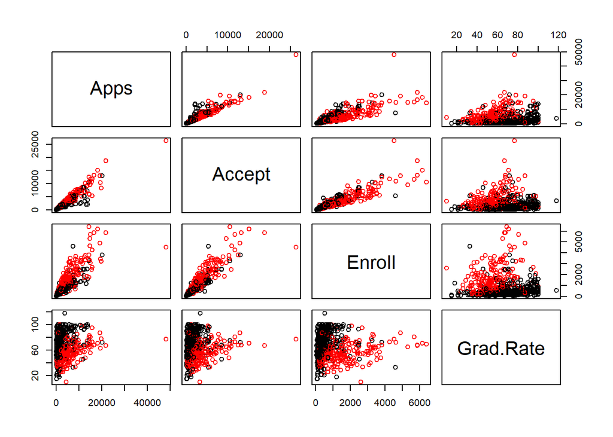

```r
# TUTORIAL SUBMISSION #######################
#1. We will use "blue" to denote private university and "red" to denote non-private
#university. To do that, first obtain a vector of character (`colors`) containing
#the value "blue" or "red" matching the university type for that row.
#Hint: you might find it useful to cast a character to factor type
#2. Using colors, generate the same plot as (b) using the same colors from `colors`

#Complete implementation...
pcolors <- NA
pcolors[college$Private == 'Yes'] <- 'blue'
pcolors[college$Private == 'No'] <- 'red'
colors<- as.factor(pcolors)

pairs(smaller_college_df, col=colors)
```

### d) Use the plot() function to produce side-by-side boxplots of Apps vs Private. Label your axes and the plot and provide a title for your plot.

boxplot() will as for y ~ group an y has to be *numeric* whereas using plot() auto detects data given and throws out a scatterplot but requires the *group* to be a factor

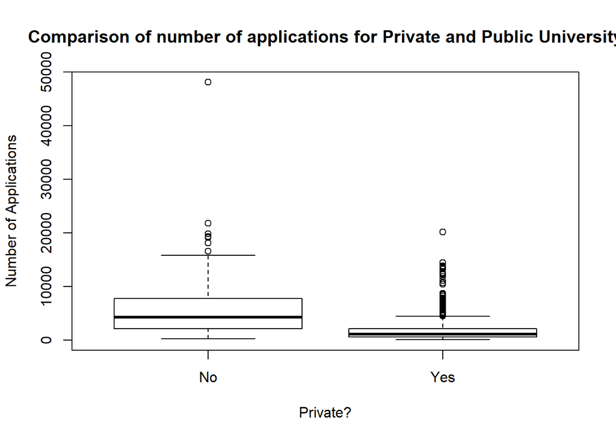

```r
# TUTORIAL SUBMISSION ###################################################

#Use the plot() function to produce a side-by-side boxplots of Apps vs Private.
#Label your x-axis "Private?", y-axis "Number of Applications", and the title
#"Comparison of number of applications for Private and Public University"
#Hint: you might find it useful to cast a character to factor type

question_d <- function(){
  #Complete implementation...
  plot(as.factor(college$Private), college$Apps, xlab = 'Private?', ylab = 'Number of Applications', main = 'Comparison of number of applications for Private and Public University')


  appsPvt <- college[c(which(colnames(college) == 'Private'),which(colnames(college) == 'Apps'))]
  appsPvt$Apps <- as.numeric(appsPvt$Apps)

  # y ~ grp
  boxplot(appsPvt$Apps~appsPvt$Private, xlab = 'Private?', ylab = 'Number of Applications', main = 'Comparison of number of applications for Private and Public University')

}
question_d()
```

```r
# My try ###############################################################

#using the airquality dataset
airquality[3:4,]
```

```
##   Ozone Solar.R Wind Temp Month Day
## 3    12     149 12.6   74     5   3
## 4    18     313 11.5   62     5   4
```

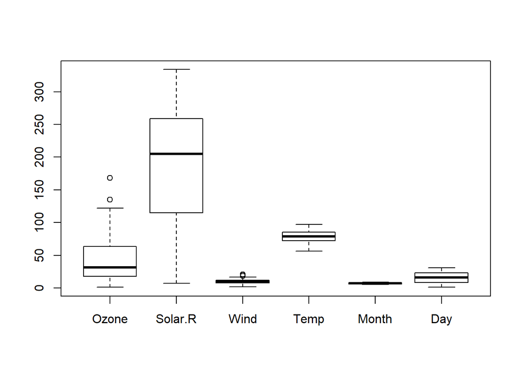

```r
boxplot(airquality)
```

### e) Produce a scatterplot based on Top10perc (percentage of new students from top 10% of the high school). Using different colors for the different percentages (<=30, <=50, <=70, >70)

#Generate the scatterplot based on Top10perc #To do that, first obtain a vector of character (`colors_top10perc`) containing #following color value: #<=30 : “red” #<=50 : “orange” #<=70 : “yellow” #>70 : “green”

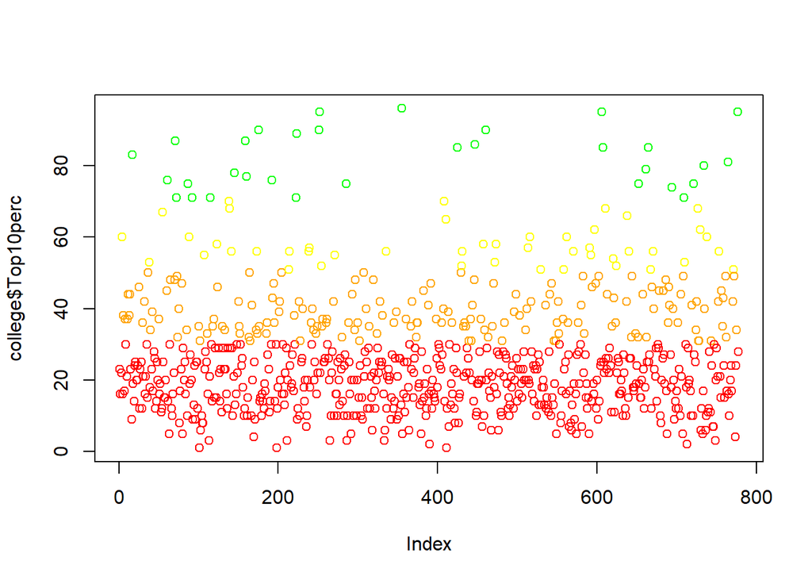

```r
colors_top10perc <- NA
colors_top10perc[college$Top10perc >  70] <- 'green'
colors_top10perc[college$Top10perc <= 70] <- 'yellow'
colors_top10perc[college$Top10perc <= 50] <- 'orange'
colors_top10perc[college$Top10perc <= 30] <- 'red'

plot(college$Top10perc, col=colors_top10perc)
```

### example for 1(e)

https://statisticsglobe.com/r-pairs-plot-example/

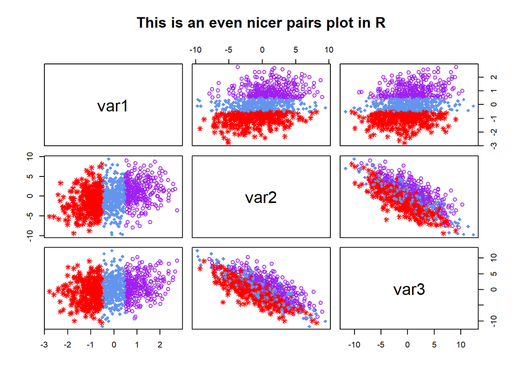

```r
set.seed(525354)                       # Set seed for reproducibility
N <- 1000                              # Sample size of 1000

x1 <- rnorm(N)                         # Create variable
x2 <- x1 + rnorm(N, 0, 3)              # Create correlated variable
x3 <- 2 * x1 - x2 + rnorm(N, 0, 2)     # Create another correlated variable

data <- data.frame(x1, x2, x3)         # Combine all variables to data.frame


# Example 4: Modify pairs R Plot by Group
# Quite often you will have different subsets or subgroups in your data. Let’s add a group
# indicator (three groups 1, 2 & 3) to our example data to simulate such a situation:
group <- NA
group[data$x1 < - 0.5] <- 1
group[data$x1 >= - 0.5 & data$x1 <= 0.5] <- 2
group[data$x1 > 0.5] <- 3

# Now, let’s apply the pairs function again, but this time dependent on the group variable:
pairs(data[ , 1:3],
      col = c("red", "cornflowerblue", "purple")[group],   # Change color by group
      pch = c(8, 18, 1)[group],                            # Change points by group
      labels = c("var1", "var2", "var3"),
      main = "This is an even nicer pairs plot in R")
```

### f) Use the hist() function to generate a histogram of Top10perc. Add in the same color coding scheme as (e)

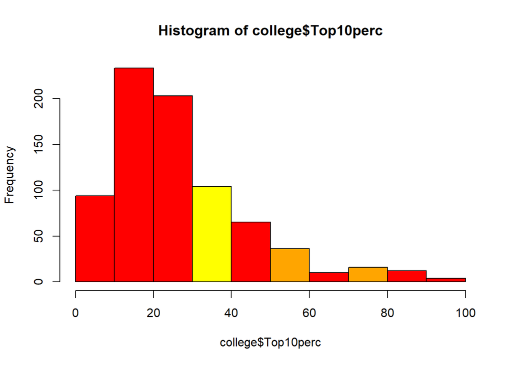

```r
question_f <- function(){
  #Complete implementation...
  hist(college$Top10perc, col=colors_top10perc)
}
question_f()
```

### g) The command par(mfrow=c(1,2)) allows you to divide the plotting window into multiple regions for plotting multiple plot. Try typing it on the console window together with the plotting commands from (f) and the (g). How can you increase the regions to allow 4 diagrams instead?

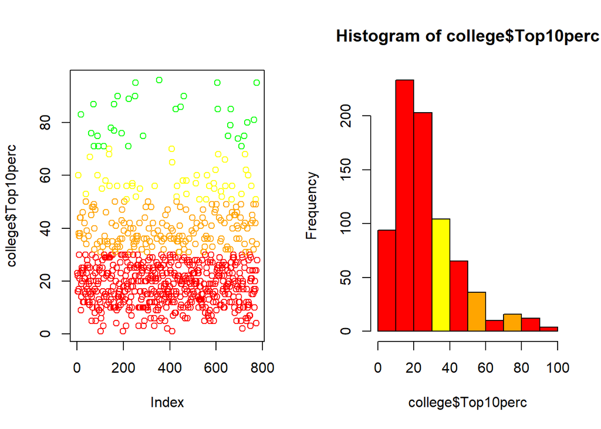

```r
par(mfrow=c(1,2))
plot(college$Top10perc, col=colors_top10perc)
hist(college$Top10perc, col=colors_top10perc)
```

### h) Try exploring the data with different charts.